# Projeto - Predição de Doenças Cardíacas utilizando Machine Learning

**Aluno:** Gabriel Citroni Uliana - NUSP: 9779367

**Disciplina:** SME0878 - Mineração Estatística de Dados  
**Professor:** Francisco Aparecido Rodrigues  
Universidade de São Paulo - ICMC, São Carlos, Brasil.  
2º Semestre - 2021

## Descrição do Projeto

Nesse projeto farei o uso dos conceitos aprendidos ao longo do semestre com o intuito de *Predizer Doenças Cardiacas utilizando Machine Learning*.  
Através do uso de diferentes técnicas e modelos, em seguida analisarei os resultados de cada um para concluir qual apresenta o melhor resultado para esse problema.

### Referências

Para esse projeto, uso como base o artigo publicado por Aman Kharwal, encontrado em: https://thecleverprogrammer.com/2020/11/10/heart-disease-prediction-using-machine-learning/

E os dados também usados nesse mesmo artigo, disponiveis em: https://raw.githubusercontent.com/amankharwal/Website-data/master/heart.csv

### Importação de Pacotes e leitura dos Dados

```python
import random
import pandas as pd
import numpy as np
import matplotlib.pyplot as plt
import seaborn as sns
from sklearn.preprocessing import StandardScaler
from sklearn.model_selection import train_test_split
```

```python
random.seed(42) # define the seed (important to reproduce the results)

df = pd.read_csv("/content/drive/MyDrive/Mineração Estatística de Dados/data/heart.csv", header=(0))
df.head(10)
```

|  | age | sex | cp | trestbps | chol | fbs | restecg | thalach | exang | oldpeak | slope | ca | thal | target |
| --- | --- | --- | --- | --- | --- | --- | --- | --- | --- | --- | --- | --- | --- | --- |
| 0 | 63 | 1 | 3 | 145 | 233 | 1 | 0 | 150 | 0 | 2.3 | 0 | 0 | 1 | 1 |
| 1 | 37 | 1 | 2 | 130 | 250 | 0 | 1 | 187 | 0 | 3.5 | 0 | 0 | 2 | 1 |
| 2 | 41 | 0 | 1 | 130 | 204 | 0 | 0 | 172 | 0 | 1.4 | 2 | 0 | 2 | 1 |
| 3 | 56 | 1 | 1 | 120 | 236 | 0 | 1 | 178 | 0 | 0.8 | 2 | 0 | 2 | 1 |
| 4 | 57 | 0 | 0 | 120 | 354 | 0 | 1 | 163 | 1 | 0.6 | 2 | 0 | 2 | 1 |
| 5 | 57 | 1 | 0 | 140 | 192 | 0 | 1 | 148 | 0 | 0.4 | 1 | 0 | 1 | 1 |
| 6 | 56 | 0 | 1 | 140 | 294 | 0 | 0 | 153 | 0 | 1.3 | 1 | 0 | 2 | 1 |
| 7 | 44 | 1 | 1 | 120 | 263 | 0 | 1 | 173 | 0 | 0.0 | 2 | 0 | 3 | 1 |
| 8 | 52 | 1 | 2 | 172 | 199 | 1 | 1 | 162 | 0 | 0.5 | 2 | 0 | 3 | 1 |
| 9 | 57 | 1 | 2 | 150 | 168 | 0 | 1 | 174 | 0 | 1.6 | 2 | 0 | 2 | 1 |

## Exploração dos Dados

Observação sobre a tabela:  
1 - age  
2 - sex  
3 - cp(Chest Pain)  
4 - trestbps(resting blood pressure)  
5 - chol  
6 - fbs  
7 - restecg(resting EKG results)  
8 - exang(exercise-induced angina)  
9 - oldpeak 10 - slope(the slope of the ST segment of peak exercise)  
11 - ca(number of major vessels(0-3) stained by fluroscopy)  
12 - thal(thalium stress result)

Informações gerais sobre o dataframe

```python
pd.set_option("display.float", "{:.2f}".format)
df.describe()
```

|  | age | sex | cp | trestbps | chol | fbs | restecg | thalach | exang | oldpeak | slope | ca | thal | target |
| --- | --- | --- | --- | --- | --- | --- | --- | --- | --- | --- | --- | --- | --- | --- |
| count | 303.00 | 303.00 | 303.00 | 303.00 | 303.00 | 303.00 | 303.00 | 303.00 | 303.00 | 303.00 | 303.00 | 303.00 | 303.00 | 303.00 |
| mean | 54.37 | 0.68 | 0.97 | 131.62 | 246.26 | 0.15 | 0.53 | 149.65 | 0.33 | 1.04 | 1.40 | 0.73 | 2.31 | 0.54 |
| std | 9.08 | 0.47 | 1.03 | 17.54 | 51.83 | 0.36 | 0.53 | 22.91 | 0.47 | 1.16 | 0.62 | 1.02 | 0.61 | 0.50 |
| min | 29.00 | 0.00 | 0.00 | 94.00 | 126.00 | 0.00 | 0.00 | 71.00 | 0.00 | 0.00 | 0.00 | 0.00 | 0.00 | 0.00 |
| 25% | 47.50 | 0.00 | 0.00 | 120.00 | 211.00 | 0.00 | 0.00 | 133.50 | 0.00 | 0.00 | 1.00 | 0.00 | 2.00 | 0.00 |
| 50% | 55.00 | 1.00 | 1.00 | 130.00 | 240.00 | 0.00 | 1.00 | 153.00 | 0.00 | 0.80 | 1.00 | 0.00 | 2.00 | 1.00 |
| 75% | 61.00 | 1.00 | 2.00 | 140.00 | 274.50 | 0.00 | 1.00 | 166.00 | 1.00 | 1.60 | 2.00 | 1.00 | 3.00 | 1.00 |
| max | 77.00 | 1.00 | 3.00 | 200.00 | 564.00 | 1.00 | 2.00 | 202.00 | 1.00 | 6.20 | 2.00 | 4.00 | 3.00 | 1.00 |

Gráfico de barras sobre o "target", para verificar se os dados estão desbalanceados

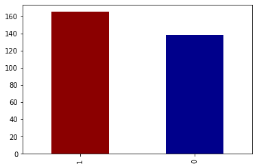

```python
df.target.value_counts().plot(kind="bar", color=["darkred", "darkblue"])
```

Nosso problema está balanceado

Verificamos se os dados possuem alguma entrada com valores nulos

```python
valores_categoricos = []
valores_continuos = []
for column in df.columns:
  print(f"{column} : {df[column].unique()}" + "\n" + "=========================")

  #salvamos quais colunas possuem valores categoricos ou continuos
  if len(df[column].unique()) <= 10:
    valores_categoricos.append(column)
  else:
    valores_continuos.append(column)
```

```
age : [63 37 41 56 57 44 52 54 48 49 64 58 50 66 43 69 59 42 61 40 71 51 65 53
 46 45 39 47 62 34 35 29 55 60 67 68 74 76 70 38 77]
=========================
sex : [1 0]
=========================
cp : [3 2 1 0]
=========================
trestbps : [145 130 120 140 172 150 110 135 160 105 125 142 155 104 138 128 108 134
 122 115 118 100 124  94 112 102 152 101 132 148 178 129 180 136 126 106
 156 170 146 117 200 165 174 192 144 123 154 114 164]
=========================
chol : [233 250 204 236 354 192 294 263 199 168 239 275 266 211 283 219 340 226
 247 234 243 302 212 175 417 197 198 177 273 213 304 232 269 360 308 245
 208 264 321 325 235 257 216 256 231 141 252 201 222 260 182 303 265 309
 186 203 183 220 209 258 227 261 221 205 240 318 298 564 277 214 248 255
 207 223 288 160 394 315 246 244 270 195 196 254 126 313 262 215 193 271
 268 267 210 295 306 178 242 180 228 149 278 253 342 157 286 229 284 224
 206 167 230 335 276 353 225 330 290 172 305 188 282 185 326 274 164 307
 249 341 407 217 174 281 289 322 299 300 293 184 409 259 200 327 237 218
 319 166 311 169 187 176 241 131]
=========================
fbs : [1 0]
=========================
restecg : [0 1 2]
=========================
thalach : [150 187 172 178 163 148 153 173 162 174 160 139 171 144 158 114 151 161
 179 137 157 123 152 168 140 188 125 170 165 142 180 143 182 156 115 149
 146 175 186 185 159 130 190 132 147 154 202 166 164 184 122 169 138 111
 145 194 131 133 155 167 192 121  96 126 105 181 116 108 129 120 112 128
 109 113  99 177 141 136  97 127 103 124  88 195 106  95 117  71 118 134
  90]
=========================
exang : [0 1]
=========================
oldpeak : [2.3 3.5 1.4 0.8 0.6 0.4 1.3 0.  0.5 1.6 1.2 0.2 1.8 1.  2.6 1.5 3.  2.4
 0.1 1.9 4.2 1.1 2.  0.7 0.3 0.9 3.6 3.1 3.2 2.5 2.2 2.8 3.4 6.2 4.  5.6
 2.9 2.1 3.8 4.4]
=========================
slope : [0 2 1]
=========================
ca : [0 2 1 3 4]
=========================
thal : [1 2 3 0]
=========================
target : [1 0]
=========================
```

Os dados estão sem valores nulos, então podemos trabalhar com eles sem problemas

Além disso, notamos que os atributos sex, cp, fbs, restecg, exang, slope, ca e thal são atributos categoricos

```python
valores_categoricos
```

```
['sex', 'cp', 'fbs', 'restecg', 'exang', 'slope', 'ca', 'thal', 'target']
```

Obtendo a matriz de correlação do dataset

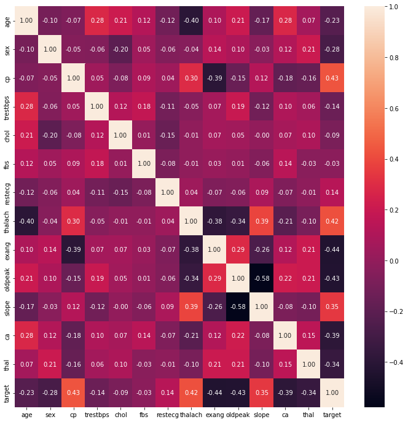

```python
corr_matrix = df.corr()
plt.figure(figsize=(12,12))
sns.heatmap(corr_matrix, annot=True, fmt=".2f")
```

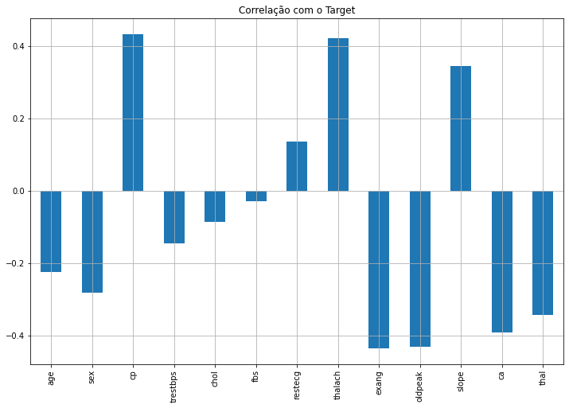

```python
df.drop('target', axis=1).corrwith(df.target).plot(kind='bar', grid=True, figsize=(12,8), title="Correlação com o Target")
```

Através de ambos os gráficos, notamos que chol e fbs são os atributos menos correlacionados com a variável alvo.

## Limpeza e Normalização dos Dados

Para trabalharmos com os modelos de machine learning, primeiro precisamos cuidar das variáveis categóricas dos nossos dados.  
Para isso, nós usamos o one-hot-encoding para transformar os atributos nominais em atributos numéricos.

```python
valores_categoricos.remove('target')#nao precisamos do OHC do target
```

```python
dataset = pd.get_dummies(df, columns = valores_categoricos)
dataset.head()
```

|  | age | trestbps | chol | thalach | oldpeak | target | sex_0 | sex_1 | cp_0 | cp_1 | cp_2 | cp_3 | fbs_0 | fbs_1 | restecg_0 | restecg_1 | restecg_2 | exang_0 | exang_1 | slope_0 | slope_1 | slope_2 | ca_0 | ca_1 | ca_2 | ca_3 | ca_4 | thal_0 | thal_1 | … |
| --- | --- | --- | --- | --- | --- | --- | --- | --- | --- | --- | --- | --- | --- | --- | --- | --- | --- | --- | --- | --- | --- | --- | --- | --- | --- | --- | --- | --- | --- | --- |
| 0 | 63 | 145 | 233 | 150 | 2.30 | 1 | 0 | 1 | 0 | 0 | 0 | 1 | 0 | 1 | 1 | 0 | 0 | 1 | 0 | 1 | 0 | 0 | 1 | 0 | 0 | 0 | 0 | 0 | 1 | … |
| 1 | 37 | 130 | 250 | 187 | 3.50 | 1 | 0 | 1 | 0 | 0 | 1 | 0 | 1 | 0 | 0 | 1 | 0 | 1 | 0 | 1 | 0 | 0 | 1 | 0 | 0 | 0 | 0 | 0 | 0 | … |
| 2 | 41 | 130 | 204 | 172 | 1.40 | 1 | 1 | 0 | 0 | 1 | 0 | 0 | 1 | 0 | 1 | 0 | 0 | 1 | 0 | 0 | 0 | 1 | 1 | 0 | 0 | 0 | 0 | 0 | 0 | … |
| 3 | 56 | 120 | 236 | 178 | 0.80 | 1 | 0 | 1 | 0 | 1 | 0 | 0 | 1 | 0 | 0 | 1 | 0 | 1 | 0 | 0 | 0 | 1 | 1 | 0 | 0 | 0 | 0 | 0 | 0 | … |
| 4 | 57 | 120 | 354 | 163 | 0.60 | 1 | 1 | 0 | 1 | 0 | 0 | 0 | 1 | 0 | 0 | 1 | 0 | 0 | 1 | 0 | 0 | 1 | 1 | 0 | 0 | 0 | 0 | 0 | 0 | … |

```python
#manipula o dataset para target ser a ultima coluna a direita
tg = dataset.target
dataset.drop(['target'], axis=1, inplace=True)
dataset['target'] = tg

#armazena os atributos do dataset, menos o target
attributes = dataset.columns[0:len(dataset.columns)-1]

#transforma a ultima coluna da tabela em string, para nao dar erros na classificacao
dataset[dataset.columns[-1]] = dataset[dataset.columns[-1]].apply(str)
#armazena as possiveis classes do target
classes = np.array(pd.unique(dataset[dataset.columns[-1]]), dtype=str)


#converte o dataset para matriz e vetor do numpy
dataset = dataset.to_numpy()
nrow,ncol = dataset.shape
y = dataset[:, -1]
X = dataset[:, 0:ncol-1]
```

Dividimos o dataset em um conjunto de treino e um conjunto teste

```python
#selecionamos os conjuntos de treinamento e teste
p=0.8
x_train, x_test, y_train, y_test = train_test_split(X, y, train_size = p, random_state = 42)
```

Normalizamos os dados, para evitar o efeito da escala dos atributos nos métodos de aprendizado.  
A normalização é feita depois da divisão dos dados, para os dados não ficarem enviesados.

```python
#normalizacao do conjunto de treinamento
scaler = StandardScaler().fit(x_train)
x_train = scaler.transform(x_train)

#normalizacao do conjunto de teste
scaler = StandardScaler().fit(x_test)
x_test = scaler.transform(x_test)
```

```python
print("Dados Transformados:")
print('Media: ', np.mean(x_train, axis = 0))
print('Desvio Padrão: ', np.std(x_train, axis = 0))
```

```
Dados Transformados:
Media:  [-1.10104763e-17  7.78991197e-16 -2.33513851e-16  2.76179447e-16
 -2.17456906e-16 -3.85366670e-17 -2.11034129e-16  2.70674208e-17
  1.44971271e-16  6.33102386e-17  1.72956232e-16  2.89942542e-16
 -3.02788098e-17  5.73462306e-17 -9.26715087e-17 -1.83737323e-16
 -2.11951668e-16  1.27538017e-16 -9.72592071e-17  6.33102386e-17
 -7.89084133e-17 -3.02788098e-17  1.33960795e-16 -1.33960795e-16
  7.70733339e-17 -4.34110966e-16 -1.23409088e-16 -8.94601198e-18
  2.38560319e-17  1.78920240e-16]
Desvio Padrão:  [1. 1. 1. 1. 1. 1. 1. 1. 1. 1. 1. 1. 1. 1. 1. 1. 1. 1. 1. 1. 1. 1. 1. 1.
 1. 1. 1. 1. 1. 1.]
```

## Análise Descritiva dos Dados

A projeção dos atributos em duas dimensões usando PCA pode dar uma ideia da separação entre as classes

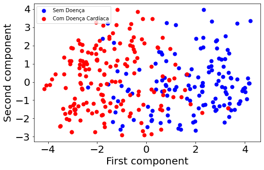

```python
from sklearn.decomposition import PCA

X_pca = X
y_pca = y

#Para a analise de componentes principais, usamos o conjunto todo
scaler = StandardScaler().fit(X_pca)
X_pca = scaler.transform(X_pca)

pca = PCA(n_components=2)
X_pca = pca.fit_transform(X_pca)
classes = np.unique(y_pca)

colors = ['blue', 'red']
aux = 0
plt.figure(figsize=(8,5))
for c in classes:
    if c == '1':
        lb = 'Com Doença Cardíaca'
    else:
        lb = 'Sem Doença'
    nodes = np.where(y_pca == c)
    plt.scatter(X_pca[nodes,0], X_pca[nodes,1], s=50, color = colors[aux], label = lb)
    aux = aux + 1

plt.legend()
plt.xlabel("First component", fontsize=20)
plt.ylabel("Second component", fontsize=20)
plt.xticks(color='k', size=20)
plt.yticks(color='k', size=20)
plt.show(True)
```

Podemos também verificar como a variância muda de acordo com o número de componentes.

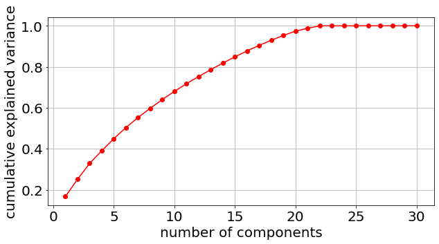

```python
X_pca = X
y_pca = y

scaler = StandardScaler().fit(X_pca)
X_pca = scaler.transform(X_pca)

pca = PCA().fit(X_pca)

plt.figure(figsize=(10,5))
ncomp = np.arange(1, np.shape(X_pca)[1]+1)
plt.plot(ncomp, np.cumsum(pca.explained_variance_ratio_), 'ro-')
plt.xlabel('number of components', fontsize=20)
plt.ylabel('cumulative explained variance', fontsize=20);
plt.xticks(color='k', size=20)
plt.yticks(color='k', size=20)
plt.grid(True)
plt.show(True)
```

Podemos observar que podemos explicar aproximadamente 90% dos dados com apenas 17 componentes.  
A exclusão das 13 componentes menos relevantes pode ajudar na classificação posterior.

## Classificação

Agora vamos comparar diversos métodos de classificação, utilizando validação cruzada.  
Para cada Classificador nós treinamos o modelo e predizemos os valores de doenças cardíacas do grupo de teste.  
Fazemos isso de 2 formas:  
1º - Com todas os dados do dataset, utilizando todos os atributos disponiveis.  
2º - Com a aplicação de Principal Component Analysis com 90% de cumulative explained variance, utilizando apenas 17 componentes do dataset

```python
from sklearn.neighbors import KNeighborsClassifier
from sklearn.model_selection import StratifiedKFold
from sklearn.model_selection import KFold
from sklearn.metrics import accuracy_score
from sklearn.metrics import roc_auc_score
```

Guardaremos o melhor resultado da média do AUC("area under the ROC curve") para cada Classificador.  
Para guardar esses valores usamos um dicionário.

```python
results = {}
```

### Classificador: K-Neighbors

Para o Modelo K-Neighbors temos várias métricas, dentre elas usaremos Euclidean, Manhattan, Chebyshev e Minkowski.

#### Métrica - Euclidean

```
Melhor k: 8  AUC: 0.8545067065287654
```

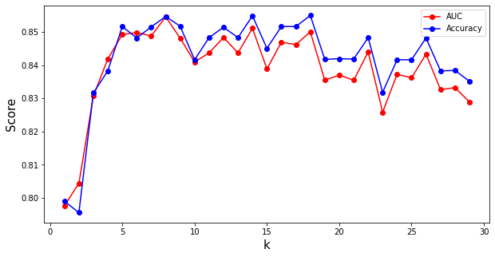

```python
cv = StratifiedKFold(n_splits=10, shuffle=True, random_state=1)

mauc = []
macc = []
vk = []
for k in range(1, 30):
    vauc = []
    vacc = []
    for train_index, test_index in cv.split(X, y):
        # select rows
        x_train, x_test = X[train_index], X[test_index]
        y_train, y_test = y[train_index], y[test_index]

        #normalizacao do conjunto de treinamento
        scaler = StandardScaler().fit(x_train)
        x_train = scaler.transform(x_train)

        #normalizacao do conjunto de teste
        scaler = StandardScaler().fit(x_test)
        x_test = scaler.transform(x_test)

        model = KNeighborsClassifier(n_neighbors=k, metric = 'euclidean')
        model.fit(x_train,y_train)
        y_pred = model.predict(x_test)
        score = accuracy_score(y_pred, y_test)

        vauc.append(roc_auc_score(y_test, y_pred))
        vacc.append(accuracy_score(y_pred, y_test))
    macc.append(np.mean(vacc))
    mauc.append(np.mean(vauc))
    vk.append(k)

best_k = np.argmax(mauc)+1

#salva o melhor resultado
results['K-Neibhors Euclidean'] = mauc[best_k-1]

print('Melhor k:', best_k, ' AUC:',mauc[best_k-1])
plt.figure(figsize=(10,5))
plt.plot(vk, mauc, '-ro', label= 'AUC')
plt.plot(vk, macc, '-bo', label = 'Accuracy')
plt.xlabel('k', fontsize = 15)
plt.ylabel('Score', fontsize = 15)
plt.legend()
plt.show()
```

##### Usando PCA

Podemos reduzir a dimensionalidade dos dados e em seguida fazer a classificação com essa nova tabela.

```
Melhor k: 8  AUC: 0.8732425662572721
```

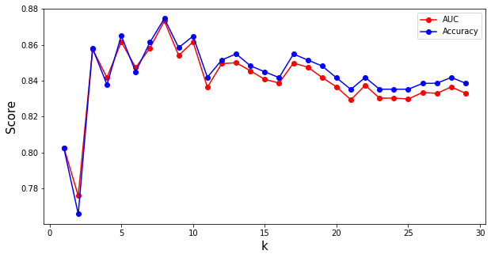

```python
cv = StratifiedKFold(n_splits=10, shuffle=True, random_state=1)

mauc = []
macc = []
vk = []

for k in range(1, 30):
    vauc = []
    vacc = []
    for train_index, test_index in cv.split(X, y):
        # select rows
        x_train, x_test = X[train_index], X[test_index]
        y_train, y_test = y[train_index], y[test_index]

        #normalizacao do conjunto de treinamento
        scaler = StandardScaler().fit(x_train)
        x_train = scaler.transform(x_train)

        #normalizacao do conjunto de teste
        scaler = StandardScaler().fit(x_test)
        x_test = scaler.transform(x_test)

        #transforma em uma nova tabela com PCA
        pca = PCA(0.9).fit(x_train)
        x_train = pca.transform(x_train)
        x_test = pca.transform(x_test)

        model = KNeighborsClassifier(n_neighbors=k, metric = 'euclidean')
        model.fit(x_train,y_train)
        y_pred = model.predict(x_test)
        score = accuracy_score(y_pred, y_test)

        vauc.append(roc_auc_score(y_test, y_pred))
        vacc.append(accuracy_score(y_pred, y_test))
    macc.append(np.mean(vacc))
    mauc.append(np.mean(vauc))
    vk.append(k)

best_k = np.argmax(mauc)+1

#salva o melhor resultado
results['K-Neibhors Euclidean(PCA)'] = mauc[best_k-1]

print('Melhor k:', best_k, ' AUC:',mauc[best_k-1])
plt.figure(figsize=(10,5))
plt.plot(vk, mauc, '-ro', label= 'AUC')
plt.plot(vk, macc, '-bo', label = 'Accuracy')
plt.xlabel('k', fontsize = 15)
plt.ylabel('Score', fontsize = 15)
plt.legend()
plt.show()
```

#### Métrica - Manhattan

```
Melhor k: 8  AUC: 0.8542441014867486
```

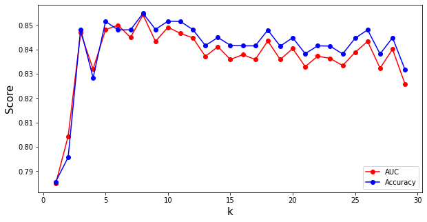

```python
cv = StratifiedKFold(n_splits=10, shuffle=True, random_state=1)

mauc = []
macc = []
vk = []
for k in range(1, 30):
    vauc = []
    vacc = []
    for train_index, test_index in cv.split(X, y):
        # select rows
        x_train, x_test = X[train_index], X[test_index]
        y_train, y_test = y[train_index], y[test_index]

        #normalizacao do conjunto de treinamento
        scaler = StandardScaler().fit(x_train)
        x_train = scaler.transform(x_train)

        #normalizacao do conjunto de teste
        scaler = StandardScaler().fit(x_test)
        x_test = scaler.transform(x_test)

        model = KNeighborsClassifier(n_neighbors=k, metric = 'manhattan')
        model.fit(x_train,y_train)
        y_pred = model.predict(x_test)
        score = accuracy_score(y_pred, y_test)

        vauc.append(roc_auc_score(y_test, y_pred))
        vacc.append(accuracy_score(y_pred, y_test))
    macc.append(np.mean(vacc))
    mauc.append(np.mean(vauc))
    vk.append(k)

best_k = np.argmax(mauc)+1

#salva o melhor resultado
results['K-Neibhors Manhattan'] = mauc[best_k-1]

print('Melhor k:', best_k, ' AUC:',mauc[best_k-1])
plt.figure(figsize=(10,5))
plt.plot(vk, mauc, '-ro', label= 'AUC')
plt.plot(vk, macc, '-bo', label = 'Accuracy')
plt.xlabel('k', fontsize = 15)
plt.ylabel('Score', fontsize = 15)
plt.legend()
plt.show()
```

##### Usando PCA

```
Melhor k: 7  AUC: 0.8571468972204267
```

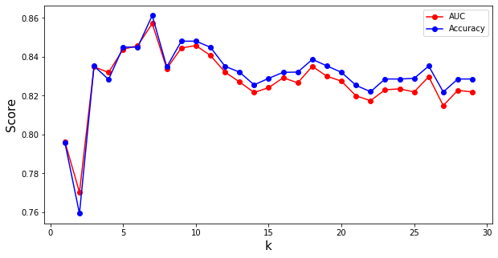

```python
cv = StratifiedKFold(n_splits=10, shuffle=True, random_state=1)

mauc = []
macc = []
vk = []

for k in range(1, 30):
    vauc = []
    vacc = []
    for train_index, test_index in cv.split(X, y):
        # select rows
        x_train, x_test = X[train_index], X[test_index]
        y_train, y_test = y[train_index], y[test_index]

        #normalizacao do conjunto de treinamento
        scaler = StandardScaler().fit(x_train)
        x_train = scaler.transform(x_train)

        #normalizacao do conjunto de teste
        scaler = StandardScaler().fit(x_test)
        x_test = scaler.transform(x_test)

        #transforma em uma nova tabela com PCA
        pca = PCA(0.9).fit(x_train)
        x_train = pca.transform(x_train)
        x_test = pca.transform(x_test)

        model = KNeighborsClassifier(n_neighbors=k, metric = 'manhattan')
        model.fit(x_train,y_train)
        y_pred = model.predict(x_test)
        score = accuracy_score(y_pred, y_test)

        vauc.append(roc_auc_score(y_test, y_pred))
        vacc.append(accuracy_score(y_pred, y_test))
    macc.append(np.mean(vacc))
    mauc.append(np.mean(vauc))
    vk.append(k)

best_k = np.argmax(mauc)+1

#salva o melhor resultado
results['K-Neibhors Manhattan(PCA)'] = mauc[best_k-1]

print('Melhor k:', best_k, ' AUC:',mauc[best_k-1])
plt.figure(figsize=(10,5))
plt.plot(vk, mauc, '-ro', label= 'AUC')
plt.plot(vk, macc, '-bo', label = 'Accuracy')
plt.xlabel('k', fontsize = 15)
plt.ylabel('Score', fontsize = 15)
plt.legend()
plt.show()
```

#### Métrica - Chebyshev

```
Melhor k: 2  AUC: 0.7696468972204266
```

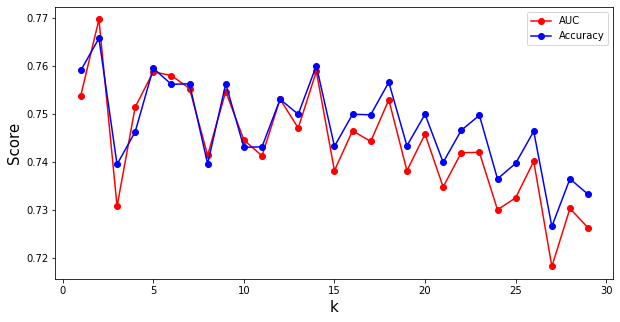

```python
cv = StratifiedKFold(n_splits=10, shuffle=True, random_state=1)

mauc = []
macc = []
vk = []
for k in range(1, 30):
    vauc = []
    vacc = []
    for train_index, test_index in cv.split(X, y):
        # select rows
        x_train, x_test = X[train_index], X[test_index]
        y_train, y_test = y[train_index], y[test_index]

        #normalizacao do conjunto de treinamento
        scaler = StandardScaler().fit(x_train)
        x_train = scaler.transform(x_train)

        #normalizacao do conjunto de teste
        scaler = StandardScaler().fit(x_test)
        x_test = scaler.transform(x_test)

        model = KNeighborsClassifier(n_neighbors=k, metric = 'chebyshev')
        model.fit(x_train,y_train)
        y_pred = model.predict(x_test)
        score = accuracy_score(y_pred, y_test)

        vauc.append(roc_auc_score(y_test, y_pred))
        vacc.append(accuracy_score(y_pred, y_test))
    macc.append(np.mean(vacc))
    mauc.append(np.mean(vauc))
    vk.append(k)

best_k = np.argmax(mauc)+1

#salva o melhor resultado
results['K-Neibhors Chebyshev'] = mauc[best_k-1]

print('Melhor k:', best_k, ' AUC:',mauc[best_k-1])
plt.figure(figsize=(10,5))
plt.plot(vk, mauc, '-ro', label= 'AUC')
plt.plot(vk, macc, '-bo', label = 'Accuracy')
plt.xlabel('k', fontsize = 15)
plt.ylabel('Score', fontsize = 15)
plt.legend()
plt.show()
```

##### Usando PCA

```
Melhor k: 8  AUC: 0.8512908047834518
```

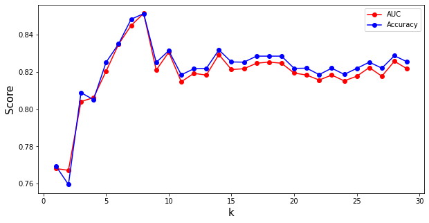

```python
cv = StratifiedKFold(n_splits=10, shuffle=True, random_state=1)

mauc = []
macc = []
vk = []

for k in range(1, 30):
    vauc = []
    vacc = []
    for train_index, test_index in cv.split(X, y):
        # select rows
        x_train, x_test = X[train_index], X[test_index]
        y_train, y_test = y[train_index], y[test_index]

        #normalizacao do conjunto de treinamento
        scaler = StandardScaler().fit(x_train)
        x_train = scaler.transform(x_train)

        #normalizacao do conjunto de teste
        scaler = StandardScaler().fit(x_test)
        x_test = scaler.transform(x_test)

        #transforma em uma nova tabela com PCA
        pca = PCA(0.9).fit(x_train)
        x_train = pca.transform(x_train)
        x_test = pca.transform(x_test)

        model = KNeighborsClassifier(n_neighbors=k, metric = 'chebyshev')
        model.fit(x_train,y_train)
        y_pred = model.predict(x_test)
        score = accuracy_score(y_pred, y_test)

        vauc.append(roc_auc_score(y_test, y_pred))
        vacc.append(accuracy_score(y_pred, y_test))
    macc.append(np.mean(vacc))
    mauc.append(np.mean(vauc))
    vk.append(k)

best_k = np.argmax(mauc)+1

#salva o melhor resultado
results['K-Neibhors Chebyshev(PCA)'] = mauc[best_k-1]

print('Melhor k:', best_k, ' AUC:',mauc[best_k-1])
plt.figure(figsize=(10,5))
plt.plot(vk, mauc, '-ro', label= 'AUC')
plt.plot(vk, macc, '-bo', label = 'Accuracy')
plt.xlabel('k', fontsize = 15)
plt.ylabel('Score', fontsize = 15)
plt.legend()
plt.show()
```

#### Métrica - Minkowski

```
Melhor k: 8  AUC: 0.8545067065287654
```

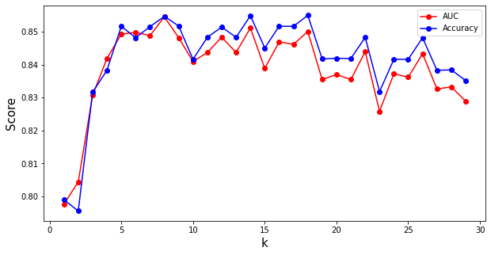

```python
cv = StratifiedKFold(n_splits=10, shuffle=True, random_state=1)

mauc = []
macc = []
vk = []
for k in range(1, 30):
    vauc = []
    vacc = []
    for train_index, test_index in cv.split(X, y):
        # select rows
        x_train, x_test = X[train_index], X[test_index]
        y_train, y_test = y[train_index], y[test_index]

        #normalizacao do conjunto de treinamento
        scaler = StandardScaler().fit(x_train)
        x_train = scaler.transform(x_train)

        #normalizacao do conjunto de teste
        scaler = StandardScaler().fit(x_test)
        x_test = scaler.transform(x_test)

        model = KNeighborsClassifier(n_neighbors=k, metric = 'minkowski')
        model.fit(x_train,y_train)
        y_pred = model.predict(x_test)
        score = accuracy_score(y_pred, y_test)

        vauc.append(roc_auc_score(y_test, y_pred))
        vacc.append(accuracy_score(y_pred, y_test))
    macc.append(np.mean(vacc))
    mauc.append(np.mean(vauc))
    vk.append(k)

best_k = np.argmax(mauc)+1

#salva o melhor resultado
results['K-Neibhors Minkowski'] = mauc[best_k-1]

print('Melhor k:', best_k, ' AUC:',mauc[best_k-1])
plt.figure(figsize=(10,5))
plt.plot(vk, mauc, '-ro', label= 'AUC')
plt.plot(vk, macc, '-bo', label = 'Accuracy')
plt.xlabel('k', fontsize = 15)
plt.ylabel('Score', fontsize = 15)
plt.legend()
plt.show()
```

##### Usando PCA

```
Melhor k: 8  AUC: 0.8732425662572721
```

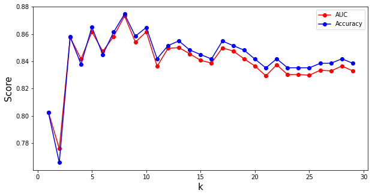

```python
cv = StratifiedKFold(n_splits=10, shuffle=True, random_state=1)

mauc = []
macc = []
vk = []

for k in range(1, 30):
    vauc = []
    vacc = []
    for train_index, test_index in cv.split(X, y):
        # select rows
        x_train, x_test = X[train_index], X[test_index]
        y_train, y_test = y[train_index], y[test_index]

        #normalizacao do conjunto de treinamento
        scaler = StandardScaler().fit(x_train)
        x_train = scaler.transform(x_train)

        #normalizacao do conjunto de teste
        scaler = StandardScaler().fit(x_test)
        x_test = scaler.transform(x_test)

        #transforma em uma nova tabela com PCA
        pca = PCA(0.9).fit(x_train)
        x_train = pca.transform(x_train)
        x_test = pca.transform(x_test)

        model = KNeighborsClassifier(n_neighbors=k, metric = 'minkowski')
        model.fit(x_train,y_train)
        y_pred = model.predict(x_test)
        score = accuracy_score(y_pred, y_test)

        vauc.append(roc_auc_score(y_test, y_pred))
        vacc.append(accuracy_score(y_pred, y_test))
    macc.append(np.mean(vacc))
    mauc.append(np.mean(vauc))
    vk.append(k)

best_k = np.argmax(mauc)+1

#salva o melhor resultado
results['K-Neibhors Minkowski(PCA)'] = mauc[best_k-1]

print('Melhor k:', best_k, ' AUC:',mauc[best_k-1])
plt.figure(figsize=(10,5))
plt.plot(vk, mauc, '-ro', label= 'AUC')
plt.plot(vk, macc, '-bo', label = 'Accuracy')
plt.xlabel('k', fontsize = 15)
plt.ylabel('Score', fontsize = 15)
plt.legend()
plt.show()
```

### Classificador: SVM

A classificação também pode ser feita através do modelo de Support Vector Machines(SVM).

```python
from sklearn.svm import SVC
```

```
Melhor c: 1  AUC: 0.8412714124111182
```

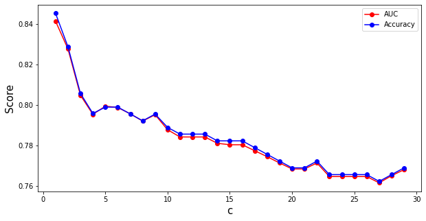

```python
cv = StratifiedKFold(n_splits=10, shuffle=True, random_state=1)

mauc = []
macc = []
vc = []
for c in range(1, 30):
    vauc = []
    vacc = []
    for train_index, test_index in cv.split(X, y):
        # select rows
        x_train, x_test = X[train_index], X[test_index]
        y_train, y_test = y[train_index], y[test_index]

        #normalizacao do conjunto de treinamento
        scaler = StandardScaler().fit(x_train)
        x_train = scaler.transform(x_train)

        #normalizacao do conjunto de teste
        scaler = StandardScaler().fit(x_test)
        x_test = scaler.transform(x_test)

        model = SVC(C=c, gamma='auto')
        model.fit(x_train,y_train)
        y_pred = model.predict(x_test)
        score = accuracy_score(y_pred, y_test)

        vauc.append(roc_auc_score(y_test, y_pred))
        vacc.append(accuracy_score(y_pred, y_test))
    macc.append(np.mean(vacc))
    mauc.append(np.mean(vauc))
    vc.append(c)

best_c = np.argmax(mauc)+1

#salva o melhor resultado
results['SVM'] = mauc[best_c-1]

print('Melhor c:', best_c, ' AUC:',mauc[best_c-1])
plt.figure(figsize=(10,5))
plt.plot(vc, mauc, '-ro', label= 'AUC')
plt.plot(vc, macc, '-bo', label = 'Accuracy')
plt.xlabel('c', fontsize = 15)
plt.ylabel('Score', fontsize = 15)
plt.legend()
plt.show()
```

Percebemos pelo gráfico que a melhor Acurácia do modelo SVM se dá para c=1, com uma grande queda relativa em relação aos outros valores.

#### Usando PCA

```
Melhor c: 1  AUC: 0.8394452973497091
```

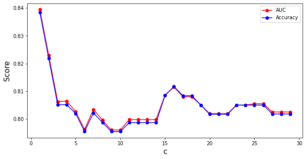

```python
cv = StratifiedKFold(n_splits=10, shuffle=True, random_state=1)

mauc = []
macc = []
vc = []
for c in range(1, 30):
    vauc = []
    vacc = []
    for train_index, test_index in cv.split(X, y):
        # select rows
        x_train, x_test = X[train_index], X[test_index]
        y_train, y_test = y[train_index], y[test_index]

        #normalizacao do conjunto de treinamento
        scaler = StandardScaler().fit(x_train)
        x_train = scaler.transform(x_train)

        #normalizacao do conjunto de teste
        scaler = StandardScaler().fit(x_test)
        x_test = scaler.transform(x_test)

        #transforma em uma nova tabela com PCA
        pca = PCA(0.9).fit(x_train)
        x_train = pca.transform(x_train)
        x_test = pca.transform(x_test)

        model = SVC(C=c, gamma='auto')
        model.fit(x_train,y_train)
        y_pred = model.predict(x_test)
        score = accuracy_score(y_pred, y_test)

        vauc.append(roc_auc_score(y_test, y_pred))
        vacc.append(accuracy_score(y_pred, y_test))
    macc.append(np.mean(vacc))
    mauc.append(np.mean(vauc))
    vc.append(c)

best_c = np.argmax(mauc)+1

#salva o melhor resultado
results['SVM (PCA)'] = mauc[best_c-1]

print('Melhor c:', best_c, ' AUC:',mauc[best_c-1])
plt.figure(figsize=(10,5))
plt.plot(vc, mauc, '-ro', label= 'AUC')
plt.plot(vc, macc, '-bo', label = 'Accuracy')
plt.xlabel('c', fontsize = 15)
plt.ylabel('Score', fontsize = 15)
plt.legend()
plt.show()
```

### Classificador: Random Forest

Para essa classificação utilizaremos o modelo Random Forest

```python
from sklearn.ensemble import RandomForestClassifier
```

```
Melhor n: 25  AUC: 0.8369242889463477
```

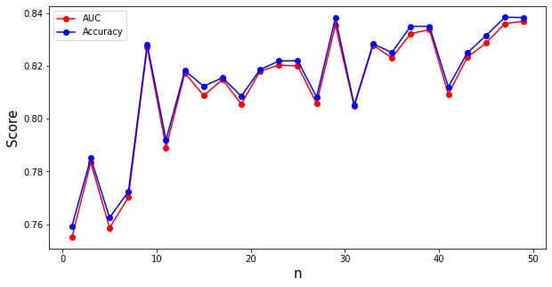

```python
cv = StratifiedKFold(n_splits=10, shuffle=True, random_state=1)

mauc = []
macc = []
vn = []
for n in range(1, 50, 2):
    vauc = []
    vacc = []
    for train_index, test_index in cv.split(X, y):
        # select rows
        x_train, x_test = X[train_index], X[test_index]
        y_train, y_test = y[train_index], y[test_index]

        #normalizacao do conjunto de treinamento
        scaler = StandardScaler().fit(x_train)
        x_train = scaler.transform(x_train)

        #normalizacao do conjunto de teste
        scaler = StandardScaler().fit(x_test)
        x_test = scaler.transform(x_test)

        model = RandomForestClassifier(n_estimators=n)
        model.fit(x_train,y_train)
        y_pred = model.predict(x_test)
        score = accuracy_score(y_pred, y_test)

        vauc.append(roc_auc_score(y_test, y_pred))
        vacc.append(accuracy_score(y_pred, y_test))
    macc.append(np.mean(vacc))
    mauc.append(np.mean(vauc))
    vn.append(n)

best_n = np.argmax(mauc)+1

#salva o melhor resultado
results['Random Forest'] = mauc[best_n-1]

print('Melhor n:', best_n, ' AUC:',mauc[best_n-1])
plt.figure(figsize=(10,5))
plt.plot(vn, mauc, '-ro', label= 'AUC')
plt.plot(vn, macc, '-bo', label = 'Accuracy')
plt.xlabel('n', fontsize = 15)
plt.ylabel('Score', fontsize = 15)
plt.legend()
plt.show()
```

Podemos verificar quais atributos possuem maior importância para a Classificação do modelo.

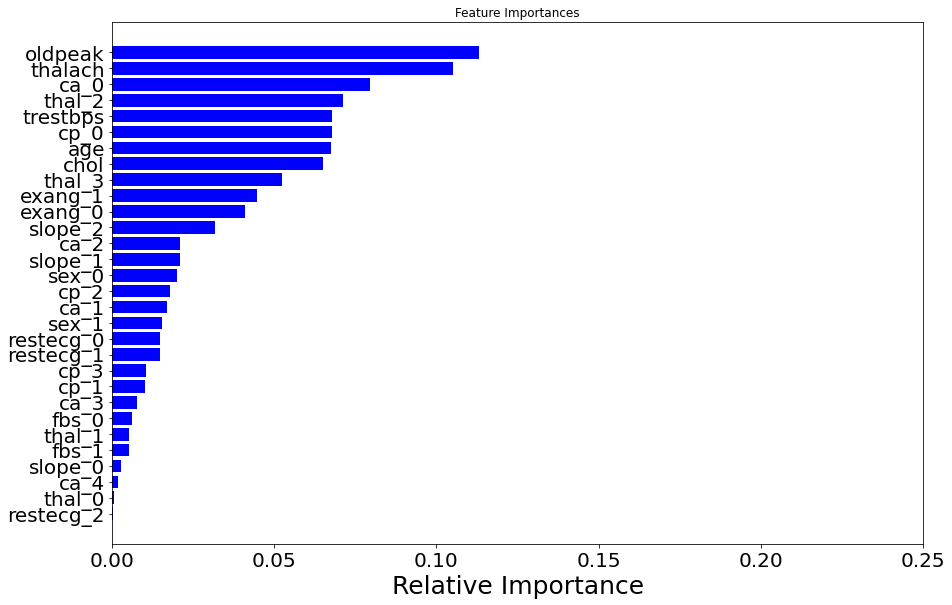

```python
importances = model.feature_importances_

indices = np.argsort(importances)
attributes_rank = []
for i in indices:
    attributes_rank.append(attributes[i])
plt.figure(figsize=(12,8))
plt.title('Feature Importances')
plt.tight_layout()
plt.barh(range(len(indices)), importances[indices], color='b', align='center')
plt.yticks(range(len(indices)), attributes_rank, fontsize=25)
plt.xlabel('Relative Importance',fontsize=25)
plt.xticks(color='k', size=20)
plt.yticks(color='k', size=20)
plt.xlim([0.0, 0.25])
plt.show()
```

#### Usando PCA

```
Melhor n: 25  AUC: 0.8361122333548803
```

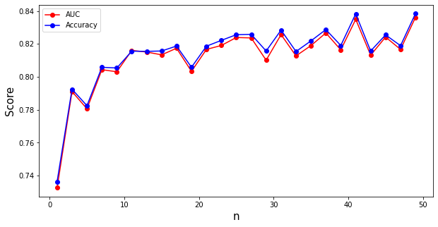

```python
cv = StratifiedKFold(n_splits=10, shuffle=True, random_state=1)

mauc = []
macc = []
vn = []
for n in range(1, 50, 2):
    vauc = []
    vacc = []
    for train_index, test_index in cv.split(X, y):
        # select rows
        x_train, x_test = X[train_index], X[test_index]
        y_train, y_test = y[train_index], y[test_index]

        #normalizacao do conjunto de treinamento
        scaler = StandardScaler().fit(x_train)
        x_train = scaler.transform(x_train)

        #normalizacao do conjunto de teste
        scaler = StandardScaler().fit(x_test)
        x_test = scaler.transform(x_test)

        #transforma em uma nova tabela com PCA
        pca = PCA(0.9).fit(x_train)
        x_train = pca.transform(x_train)
        x_test = pca.transform(x_test)

        model = RandomForestClassifier(n_estimators=n)
        model.fit(x_train,y_train)
        y_pred = model.predict(x_test)
        score = accuracy_score(y_pred, y_test)

        vauc.append(roc_auc_score(y_test, y_pred))
        vacc.append(accuracy_score(y_pred, y_test))
    macc.append(np.mean(vacc))
    mauc.append(np.mean(vauc))
    vn.append(n)

best_n = np.argmax(mauc)+1

#salva o melhor resultado
results['Random Forest (PCA)'] = mauc[best_n-1]

print('Melhor n:', best_n, ' AUC:',mauc[best_n-1])
plt.figure(figsize=(10,5))
plt.plot(vn, mauc, '-ro', label= 'AUC')
plt.plot(vn, macc, '-bo', label = 'Accuracy')
plt.xlabel('n', fontsize = 15)
plt.ylabel('Score', fontsize = 15)
plt.legend()
plt.show()
```

### Classificador: Naive Bayes

```python
from sklearn.naive_bayes import GaussianNB
from sklearn.naive_bayes import BernoulliNB
```

#### Gaussian Naive Bayes

Para a classificação utilizando o Gaussian Naive Bayes nós assumimos que os dados possuem uma distribuição Normal.

```python
cv = StratifiedKFold(n_splits=10, shuffle=True, random_state=1)

nbauc = []
nbacc = []

for train_index, test_index in cv.split(X, y):
    # select rows
    x_train, x_test = X[train_index], X[test_index]
    y_train, y_test = y[train_index], y[test_index]

    #normalizacao do conjunto de treinamento
    scaler = StandardScaler().fit(x_train)
    x_train = scaler.transform(x_train)

    #normalizacao do conjunto de teste
    scaler = StandardScaler().fit(x_test)
    x_test = scaler.transform(x_test)

    model = GaussianNB()
    model.fit(x_train,y_train)
    y_pred = model.predict(x_test)
    score = accuracy_score(y_pred, y_test)

    #necessario para nao produzir warnings por conta do target nao numerico
    y_test = np.array(y_test, dtype=float)
    y_pred = np.array(y_pred, dtype=float)

    nbauc.append(roc_auc_score(y_test, y_pred))
    nbacc.append(accuracy_score(y_pred, y_test))

#salva resultado da media
results['Gaussian NB'] = np.mean(nbauc)

print('Average accuracy:', np.mean(nbacc))
print('Average AUC:', np.mean(nbauc))
```

```
Average accuracy: 0.7420430107526881
Average AUC: 0.7396816418875243
```

###### Usando PCA

```python
cv = StratifiedKFold(n_splits=10, shuffle=True, random_state=1)

nbauc = []
nbacc = []

for train_index, test_index in cv.split(X, y):
    # select rows
    x_train, x_test = X[train_index], X[test_index]
    y_train, y_test = y[train_index], y[test_index]

    #normalizacao do conjunto de treinamento
    scaler = StandardScaler().fit(x_train)
    x_train = scaler.transform(x_train)

    #normalizacao do conjunto de teste
    scaler = StandardScaler().fit(x_test)
    x_test = scaler.transform(x_test)

    #transforma em uma nova tabela com PCA
    pca = PCA(0.9).fit(x_train)
    x_train = pca.transform(x_train)
    x_test = pca.transform(x_test)

    model = GaussianNB()
    model.fit(x_train,y_train)
    y_pred = model.predict(x_test)
    score = accuracy_score(y_pred, y_test)

    #necessario para nao produzir warnings por conta do target nao numerico
    y_test = np.array(y_test, dtype=float)
    y_pred = np.array(y_pred, dtype=float)

    nbauc.append(roc_auc_score(y_test, y_pred))
    nbacc.append(accuracy_score(y_pred, y_test))

#salva resultado da media
results['Gaussian NB (PCA)'] = np.mean(nbauc)

print('Average accuracy:', np.mean(nbacc))
print('Average AUC:', np.mean(nbauc))
```

```
Average accuracy: 0.8052688172043011
Average AUC: 0.8057813510019392
```

#### Bernoulli Naive Bayes

Para essa classificação nós precisamos assumir que os atributos possuem distruibuição de Bernoulli.

```python
cv = StratifiedKFold(n_splits=10, shuffle=True, random_state=1)

nbauc = []
nbacc = []

for train_index, test_index in cv.split(X, y):
    # select rows
    x_train, x_test = X[train_index], X[test_index]
    y_train, y_test = y[train_index], y[test_index]

    #normalizacao do conjunto de treinamento
    scaler = StandardScaler().fit(x_train)
    x_train = scaler.transform(x_train)

    #normalizacao do conjunto de teste
    scaler = StandardScaler().fit(x_test)
    x_test = scaler.transform(x_test)

    model = BernoulliNB()
    model.fit(x_train,y_train)
    y_pred = model.predict(x_test)
    score = accuracy_score(y_pred, y_test)
    #print('score parcial:', score)

    #necessario para nao produzir warnings por conta do target nao numerico
    y_test = np.array(y_test, dtype=float)
    y_pred = np.array(y_pred, dtype=float)

    nbauc.append(roc_auc_score(y_test, y_pred))
    nbacc.append(accuracy_score(y_pred, y_test))

#salva resultado da media
results['Bernoulli NB'] = np.mean(nbauc)

print('Average accuracy:', np.mean(nbacc))
print('Average AUC:', np.mean(nbauc))
```

```
Average accuracy: 0.8479569892473118
Average AUC: 0.8490829023917259
```

##### Usando PCA

```python
cv = StratifiedKFold(n_splits=10, shuffle=True, random_state=1)

nbauc = []
nbacc = []

for train_index, test_index in cv.split(X, y):
    # select rows
    x_train, x_test = X[train_index], X[test_index]
    y_train, y_test = y[train_index], y[test_index]

    #normalizacao do conjunto de treinamento
    scaler = StandardScaler().fit(x_train)
    x_train = scaler.transform(x_train)

    #normalizacao do conjunto de teste
    scaler = StandardScaler().fit(x_test)
    x_test = scaler.transform(x_test)

    #transforma em uma nova tabela com PCA
    pca = PCA(0.9).fit(x_train)
    x_train = pca.transform(x_train)
    x_test = pca.transform(x_test)

    model = BernoulliNB()
    model.fit(x_train,y_train)
    y_pred = model.predict(x_test)
    score = accuracy_score(y_pred, y_test)
    #print('score parcial:', score)

    #necessario para nao produzir warnings por conta do target nao numerico
    y_test = np.array(y_test, dtype=float)
    y_pred = np.array(y_pred, dtype=float)

    nbauc.append(roc_auc_score(y_test, y_pred))
    nbacc.append(accuracy_score(y_pred, y_test))

#salva resultado da media
results['Bernoulli NB (PCA)'] = np.mean(nbauc)

print('Average accuracy:', np.mean(nbacc))
print('Average AUC:', np.mean(nbauc))
```

```
Average accuracy: 0.8416129032258064
Average AUC: 0.8425702973497092
```

### Logistic Regression

Por último, temos o modelo de regressão logística, com o uso de aprendizado supervisionado.

```python
from sklearn.linear_model import LogisticRegression
```

```python
cv = StratifiedKFold(n_splits=10, shuffle=True, random_state=1)

lrauc = []
lracc = []

for train_index, test_index in cv.split(X, y):
    # select rows
    x_train, x_test = X[train_index], X[test_index]
    y_train, y_test = y[train_index], y[test_index]

    #normalizacao do conjunto de treinamento
    scaler = StandardScaler().fit(x_train)
    x_train = scaler.transform(x_train)

    #normalizacao do conjunto de teste
    scaler = StandardScaler().fit(x_test)
    x_test = scaler.transform(x_test)

    model = LogisticRegression()
    model.fit(x_train,y_train)
    y_pred = model.predict(x_test)
    score = accuracy_score(y_pred, y_test)
    #print('score parcial:', score)

    lrauc.append(roc_auc_score(y_test, y_pred))
    lracc.append(accuracy_score(y_pred, y_test))

#salva resultado da media
results['Logistic Regression'] = np.mean(lrauc)

print('Average accuracy:', np.mean(lracc))
print('Average AUC:', np.mean(lrauc))
```

```
Average accuracy: 0.8579569892473117
Average AUC: 0.8557409502262443
```

#### Usando PCA

```python
cv = StratifiedKFold(n_splits=10, shuffle=True, random_state=1)

lrauc = []
lracc = []

for train_index, test_index in cv.split(X, y):
    # select rows
    x_train, x_test = X[train_index], X[test_index]
    y_train, y_test = y[train_index], y[test_index]

    #normalizacao do conjunto de treinamento
    scaler = StandardScaler().fit(x_train)
    x_train = scaler.transform(x_train)

    #normalizacao do conjunto de teste
    scaler = StandardScaler().fit(x_test)
    x_test = scaler.transform(x_test)

    #transforma em uma nova tabela com PCA
    pca = PCA(0.9).fit(x_train)
    x_train = pca.transform(x_train)
    x_test = pca.transform(x_test)

    model = LogisticRegression()
    model.fit(x_train,y_train)
    y_pred = model.predict(x_test)
    score = accuracy_score(y_pred, y_test)
    #print('score parcial:', score)

    lrauc.append(roc_auc_score(y_test, y_pred))
    lracc.append(accuracy_score(y_pred, y_test))

#salva resultado da media
results['Logistic Regression (PCA)'] = np.mean(lrauc)

print('Average accuracy:', np.mean(lracc))
print('Average AUC:', np.mean(lrauc))
```

```
Average accuracy: 0.8283870967741935
Average AUC: 0.8275513089851325
```

## Conclusão

Apresentamos os melhores resultados para cada Classificador, de forma ordenada.

```python
sorted_keys = sorted(results, key=results.get, reverse=True)

for k in sorted_keys:
    print(k,':',results[k])
```

```
K-Neibhors Euclidean(PCA) : 0.8732425662572721
K-Neibhors Minkowski(PCA) : 0.8732425662572721
K-Neibhors Manhattan(PCA) : 0.8571468972204267
Logistic Regression : 0.8557409502262443
K-Neibhors Euclidean : 0.8545067065287654
K-Neibhors Minkowski : 0.8545067065287654
K-Neibhors Manhattan : 0.8542441014867486
K-Neibhors Chebyshev(PCA) : 0.8512908047834518
Bernoulli NB : 0.8490829023917259
Bernoulli NB (PCA) : 0.8425702973497092
SVM : 0.8412714124111182
SVM (PCA) : 0.8394452973497091
Random Forest : 0.8369242889463477
Random Forest (PCA) : 0.8361122333548803
Logistic Regression (PCA) : 0.8275513089851325
Gaussian NB (PCA) : 0.8057813510019392
K-Neibhors Chebyshev : 0.7696468972204266
Gaussian NB : 0.7396816418875243
```

Representando os resultados de forma gráfica.

```
<BarContainer object of 18 artists>
```

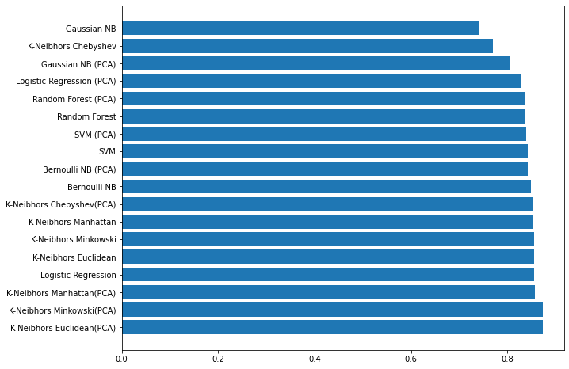

```python
valores = [results[k] for k in sorted_keys]

#valores.type()
plt.figure(figsize=(10,8))
plt.barh(sorted_keys, valores)
```

Podemos notar que o uso de Principal Component Analysis foi decisivo para melhorar a predição para os modelos de K-Neighbors.  
Fazendo com que KNN - Euclidean (PCA), KNN- Minkowski (PCA) produzissem os melhor resultados para o nosso dataset.  
Por outro lado, se não usassemos PCA o melhor modelo seria o Logistic Regression, um modelo de aprendizado supervisionado.